# ANLT_232_Assignment_2

It seems that median would be better than mean for yearly MPG because some outliers would make mean an unrealistic parameter for comparison. Because of this issue, we made two following graph. first one is median MPG of each year in US. Second diagram shows median MPG for makes from Japan and US.

```
Text(0.5,1,'Rapid Increase in Median MPG \nOver Last 10 years')
```

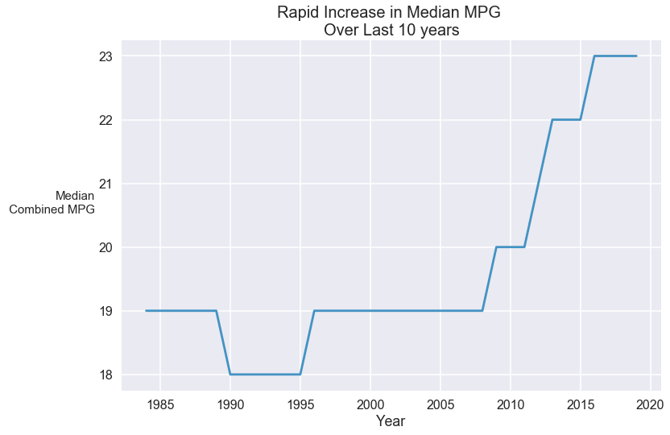

```python
#Ali's code

mpg_by_year = vehicles_df.groupby('year')['comb08'].median()

#plot mpg over time
plt.figure()
plt.plot(mpg_by_year.index, mpg_by_year, color='#4393c3')
plt.ylabel("Median\n Combined MPG",rotation=0,horizontalalignment='right',fontsize=15)
plt.xlabel("Year")
plt.title("Rapid Increase in Median MPG \nOver Last 10 years",fontsize=20)
```

It shows that median MPG is increasing over time that is reasonable. Additionally this increase started 2007 or 10 years ago and not 3 decades agao.

```
Text(0.5,1,"Comparion of MPG's \n between US and Japaneese makes")
```

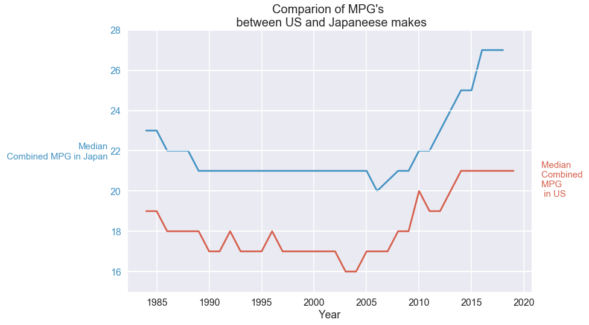

```python
#Ali's code

Japan_vehicles_df=vehicles_df[vehicles_df['region'] == 'Japan']
US_vehicles_df=vehicles_df[vehicles_df['region'] == 'United States']
Japan_mpg_by_year = Japan_vehicles_df.groupby('year')['comb08'].median() # get the average MPG for all cars in each year of production
US_mpg_by_year = US_vehicles_df.groupby('year')['comb08'].median()

#plot mpg over time
fig, ax1 = plt.subplots()
plt.figure()
ax1.plot(Japan_mpg_by_year.index, Japan_mpg_by_year, color='#4393c3')
ax1.set_ylim(15,28)
ax1.set_ylabel("Median\n Combined MPG in Japan",color='#4393c3',rotation=0,horizontalalignment='right',fontsize=15)
ax1.set_xlabel("Year")
ax1.tick_params('y', colors='#4393c3')




ax2 = ax1.twinx()
ax2.plot(US_mpg_by_year.index, US_mpg_by_year, color='#d6604d')
ax2.set_ylim(15,28)
ax2.set_ylabel("Median \nCombined \nMPG \n in US", color='#d6604d',rotation=0,horizontalalignment='left',fontsize=15)
ax2.set_yticklabels([])
ax2.tick_params('y', colors='#d6604d')
ax2.set_title("Comparion of MPG's \n between US and Japaneese makes",fontsize=20)
```

Above diagram shows that Japaneese manufacturers did better than US ones from 1985 until now definitely. I think that main reason of this issue is not technological and it is because of cultural properties of east Asia. They are trying to pay less and save more in a lot of ascpects of their life but US people do not think same to them.

```
Text(0.5,1,'Inverse Relationship Between\n MPG and Emissions')
```

[figure not shown]

```python
emissions_by_year = vehicles_df.groupby('year')['co2TailpipeGpm'].mean() # get the average C02 emissions

# plot both emissions and mpg over time together
fig, ax1 = plt.subplots()
ax1.plot(mpg_by_year.index, mpg_by_year, color='#d6604d')
ax1.set_ylabel("Average \nCombined \nMPG", color='#d6604d',rotation=0,horizontalalignment='right',fontsize=15)
ax1.set_xlabel("Year",fontsize=15)
ax1.tick_params('y', colors='#d6604d')

ax2 = ax1.twinx()
ax2.plot(emissions_by_year.index, emissions_by_year, color='#4393c3')
ax2.set_ylabel("Average \nCO2 \nEmissions \n(grams/mile)", color='#4393c3',rotation=0,horizontalalignment='left',fontsize=15)
ax2.tick_params('y', colors='#4393c3')
ax2.set_title("Inverse Relationship Between\n MPG and Emissions",fontsize=20)
```

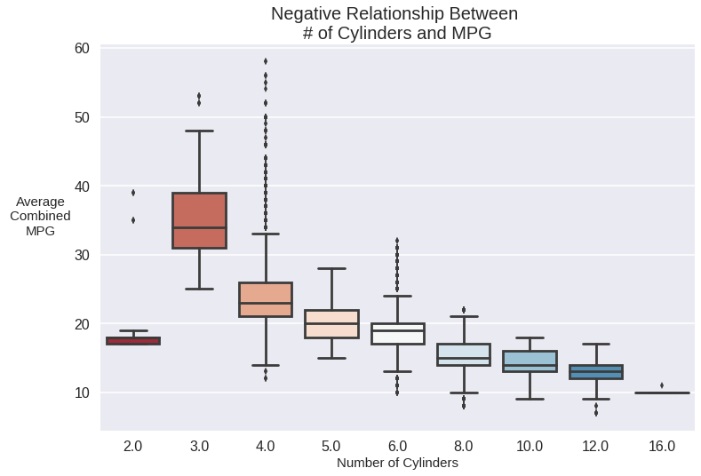

```python
cyl_plot = sns.boxplot('cylinders', 'comb08', data=vehicles_df,palette = 'RdBu')
plt.ylabel("Average\n Combined \nMPG", rotation =0,fontsize=15)
plt.xlabel("Number of Cylinders",fontsize=15)
plt.title("Negative Relationship Between \n# of Cylinders and MPG",fontsize=20)
cyl_plot.yaxis.set_label_coords(-0.1,.5)
```

This plot shows the negative relationship between the **Number of Cylinders** in the vehicles engine and the **Average Combined MPG**. Although increasing the **Number of Cylinders** or displacement of an engine could create more power, the loss in fuel efficiency is a tradeoff worth considering.